# Submitted data error checks

# 0. Instructions for submitters

Submitters should use this file to check for problems with submitted data. Each of these html files contains a summary of the data from a single submitted spreadsheet file. The html name is based on the name of the submitted file. Use the details below to check:

- Institute abbreviation, submitter and contributor names
- The plot location(s), using the map zoom and pan features if needed
- For problems in the first sections; “OK” means there are no problems in a particular section, “warning” is something that should be checked (but might be OK), “error” is a problem that needs to be addressed
- For numeric values outside the expected range in the “Value checks” section
- Variables with missing values–are there any missing that you thought you included?
- Plots of flux, cumulative emission over time, and final cumulative emission for strange patterns, unexpectedly high or low values
- Plots of weather data for appropriate differences between plots and expected diurnal or other patterns
- Plots of manure and application data for correct values

Finally, the numeric summary at the end might provide details that can help in pinpointing problems, but typically does not need to be checked.

# 1. Submitter

| inst.abbrev | submitter | version | date |
| --- | --- | --- | --- |
| AU | Pedersen, Johanna | 1 | 2022-07-07 |

# 2. Contributors

| contributor | institute |
| --- | --- |
| Nyord, Tavs | Aarhus Universitet |

# 3. File and directory names

```
## [1] "../../data-submitted/03/AU"
```

```
## [1] "../../data-submitted/03/AU/ALFAM2_template_6_0_220126_JP_20CD21A_JP.xlsx"
```

# 4. Location

[interactive chart not shown]

# 5.Keys and codes

## Codes in Treatments sheet

```
## OK
```

```
## OK
```

## Codes in Plots sheet

```
## OK
```

```
## OK
```

## Codes in Emission sheet

```
## OK
```

```
## OK
```

## Code merge check (matching project, experiment, field, plot, treatment)

```
## OK
```

```
## OK
```

```
## OK
```

```
## OK
```

```
## OK
```

# 6. Publication info

## Check for missing codes

```
## [1] "Missing pub codes in Publications sheet."
```

```
## OK
```

## Complete citations given

```
## OK
```

```
## OK
```

# 7. Emission sheet

## Duplicated intervals

```
## OK
```

## Missing incorporation time

```
## OK
```

## Delay after application

```
## OK
```

## Missing or double interval number

```
## [1] "Problem, see following rows"
## [1] 477 481 480 476 524
##
## head() of problem rows:
##   row.in.file.int plot interval             t.start
## 1             477   10       18 2020-06-04 21:13:00
## 2             481   10       22 2020-06-05 04:09:00
## 3             478   10       19 2020-06-04 22:57:00
## 4             479   10       20 2020-06-05 00:41:00
## 5             480   10       21 2020-06-05 02:25:00
## 8             460   10        1 2020-06-03 15:53:00
## [1] "Problem, see following rows"
## [1] 69
##
## head() of problem rows:
##     row.in.file.int plot interval             t.start
## 6                68    1       64 2020-06-08 03:45:00
## 7                69    1       65 2020-06-08 05:29:00
## 146               5    1        1 2020-06-03 14:41:00
## OK
## OK
## [1] "Problem, see following rows"
## [1] 329
##
## head() of problem rows:
##     row.in.file.int plot interval             t.start
## 235             328    6       64 2020-06-08 04:25:00
## 236             329    6       65 2020-06-08 06:09:00
## 536             265    6        1 2020-06-03 15:21:00
## OK
## OK
## OK
## OK
## [1] "Problem, see following rows"
## [1] 826
##
## head() of problem rows:
##     row.in.file.int plot interval             t.start
## 602             825   12       77 2020-06-15 02:49:00
## 603             826   12       78 2020-06-15 04:33:00
```

[output cut: 33 more lines]

```
## 1726            1886    9       72 2021-03-21 19:39:00
## 1727            1887    9       73 2021-03-21 21:23:00
## 1858            1815    9        1 2021-03-16 17:35:00
## [1] "Problem, see following rows"
## [1] 1789 1765 1814 1802 1797
##
## head() of problem rows:
##      row.in.file.int plot interval             t.start
## 1750            1788    8       47 2021-03-20 01:11:00
## 1751            1789    8       48 2021-03-20 02:55:00
## 1825            1742    8        1 2021-03-16 17:27:00
## 1847            1764    8       23 2021-03-18 07:35:00
## 1848            1765    8       24 2021-03-18 09:19:00
## 1849            1806    8       65 2021-03-21 07:23:00
## OK
```

## Missing time between intervals

```
## [1] "Problem, see following rows (compare start time to end time in previous rows):"
## [1] 481 478 460 517 482
## [1] "Problem, see following rows (compare start time to end time in previous rows):"
## [1] 5
## OK
## OK
## [1] "Problem, see following rows (compare start time to end time in previous rows):"
## [1] 265
## OK
## OK
## OK
## OK
## [1] "Problem, see following rows (compare start time to end time in previous rows):"
## [1] 749
## OK
## OK
## OK
## OK
## [1] "Problem, see following rows (compare start time to end time in previous rows):"
## [1] 1147
## OK
## OK
## OK
## [1] "Problem, see following rows (compare start time to end time in previous rows):"
## [1] 1450
## OK
## OK
## OK
## OK
## [1] "Problem, see following rows (compare start time to end time in previous rows):"
## [1] 1815
## [1] "Problem, see following rows (compare start time to end time in previous rows):"
## [1] 1742 1806 1798 1790 1803
## OK
```

## Measurement method and units

Measurement technique:

| Method | Frequency |
| --- | --- |
| Wind tunnel | 1883 |

Measurement technique classification:

| Classification | Frequency |
| --- | --- |
| wt | 1883 |

Emission units and conversion factors.

|  | Original unit | Conversion factor applied | Final unit |
| --- | --- | --- | --- |
| 1 | kg NH3/ha-hr | 0.8224414 | kg N/ha-hr |
| 21 | NA | NA | kg N/ha-hr |

# 7. Value checks

Check to see if submitted values are within a reasonable range.

## Weather

```
## wind : OK
## rain.rate : OK
## air.temp : OK
## soil.temp : OK
## soil.temp.surf : No values to check.
## air.temp.z : OK
## wind.z : No values to check.
```

## Manure and application

```
## man.stor : No values to check.
## man.dm : OK
## man.vs : No values to check.
## man.tkn : OK
## man.tan : OK
## man.tic : No values to check.
## man.ua : No values to check.
## man.vfa : No values to check.
## man.ph : OK
## app.rate : OK
## crop.z : No values to check.
```

## Emission

```
## j.NH3 : OK
## e.int : OK
## e.rel : OK
```

# 8. Missing values

Check for missing values.

## All variables

```
## Some values missing:
## Table below has number of missing observations by variable:
##          pub.id   meas.tech.det            clay            silt            sand
##             583            1883            1883            1883            1883
##              oc    soil.water.v      soil.moist  man.source.det        man.stor
##            1883            1883            1883            1883            1883
##          man.vs         man.tic          man.ua         man.vfa     time.incorp
##            1883            1883            1883            1883            1883
##        man.area        dist.inj        furrow.z        furrow.w          crop.z
##            1883            1883            1883            1883            1883
##       crop.area             lai      notes.plot           bg.dl          bg.val
##            1883            1883            1818            1883              20
##         bg.unit         pH.surf      air.temp.z     soil.temp.z  soil.temp.surf
##              20            1883              20              20            1883
##             rad          wind.z             MOL           ustar              rl
##            1883            1883            1883            1883            1883
##        air.pres   air.pres.unit              rh        wind.loc         far.loc
##            1883            1883            1883            1883            1883
##       notes.int j.NH3.unit.orig      j.NH3.orig j.NH3.conv.fact         wind.2m
##            1882              20              20              20            1883
##        pub.info      soil.type2          exper2            rep2
##             583            1883            1883            1883
```

## Application method and measurement method

```
## OK
```

```
## OK
```

# 9. Plots

## Calculated cumulative emission

Cumulative emission. Missing values imputed (linear interpolation).

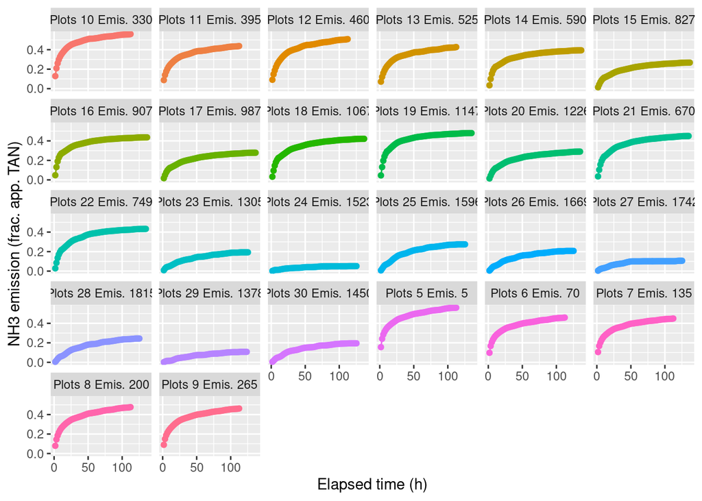

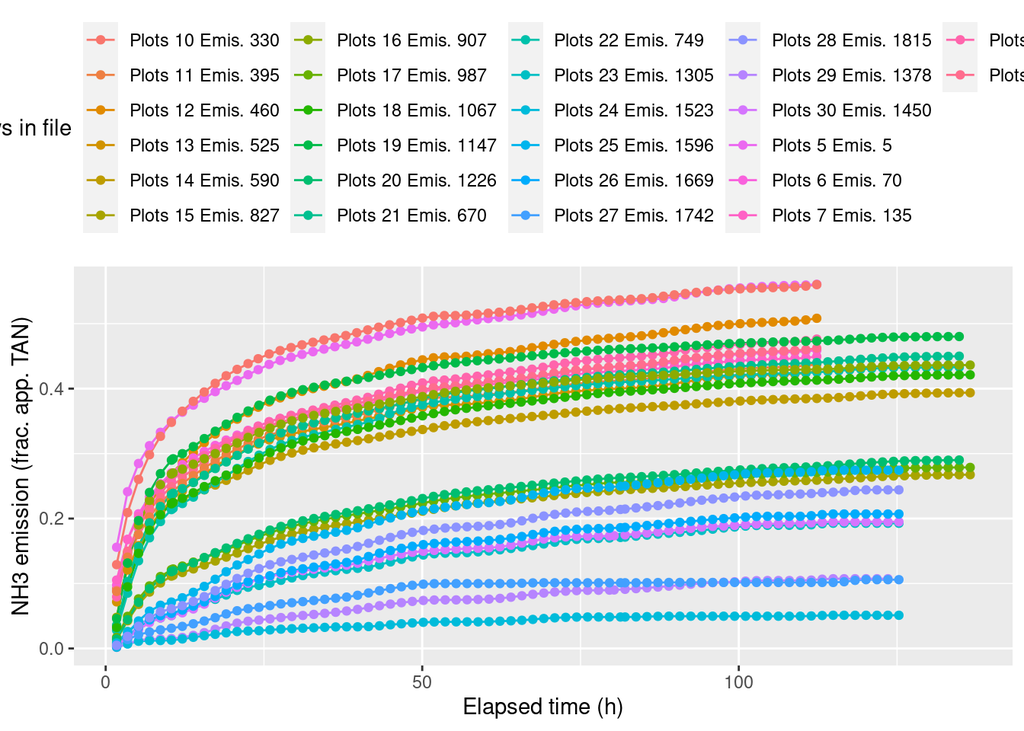

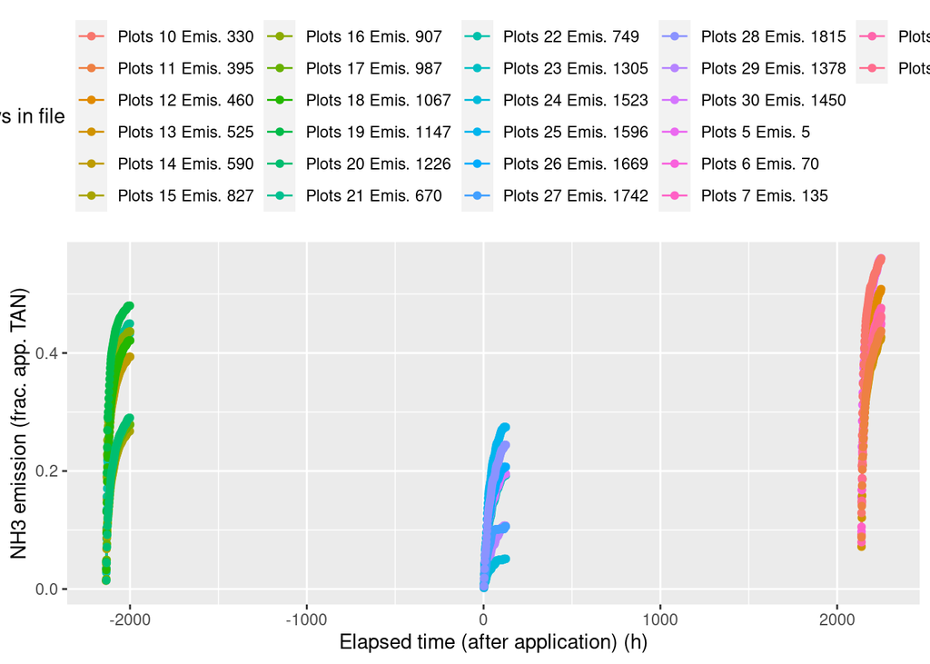

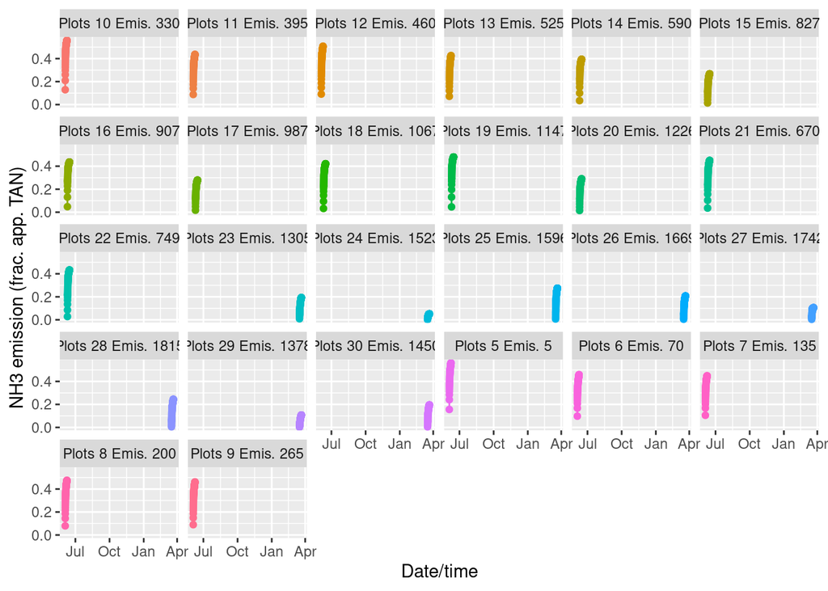

## Final cumulative emission

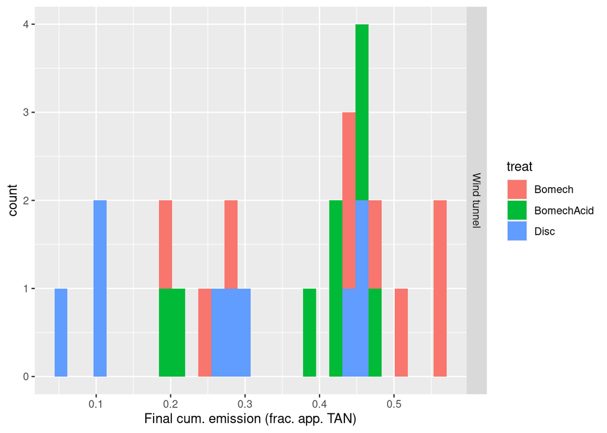

## Relative versus absolute emission

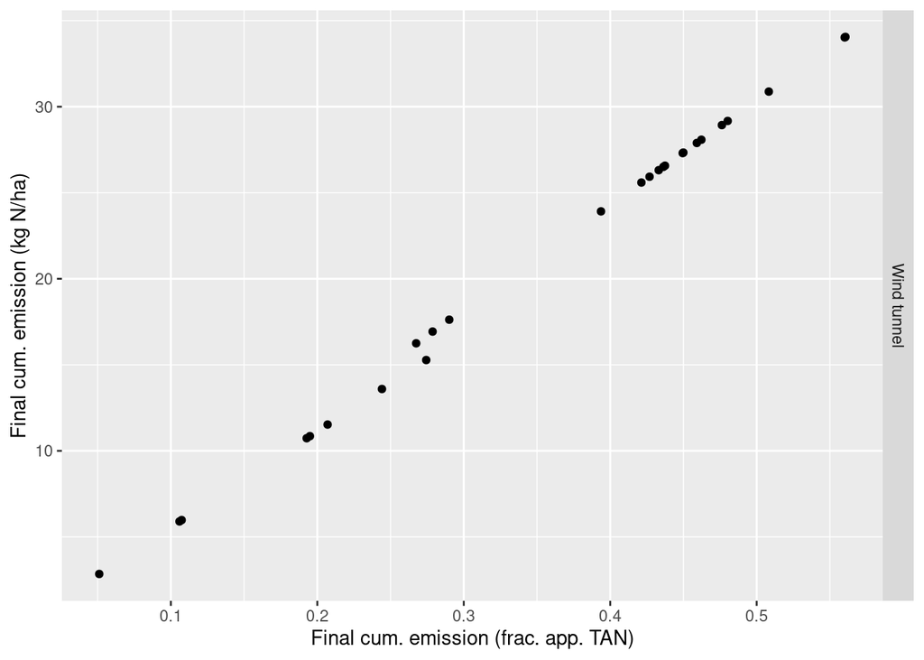

## Flux

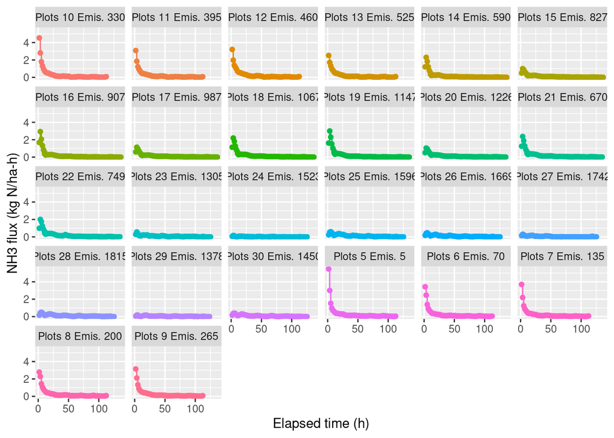

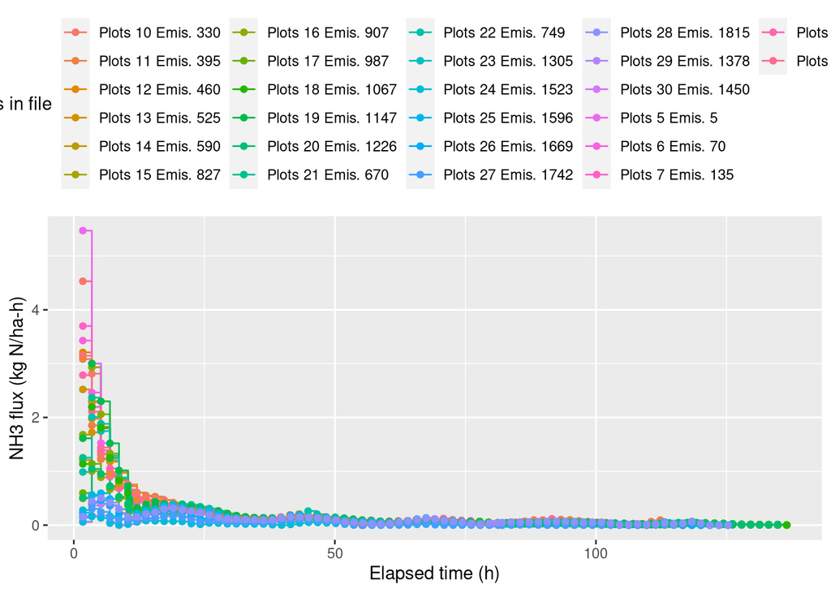

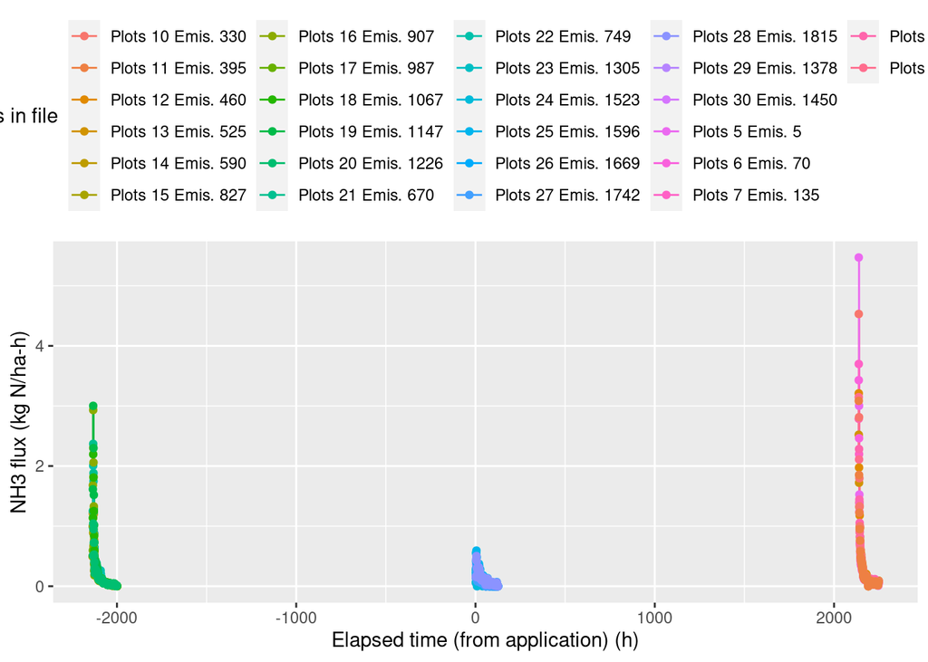

## Weather data

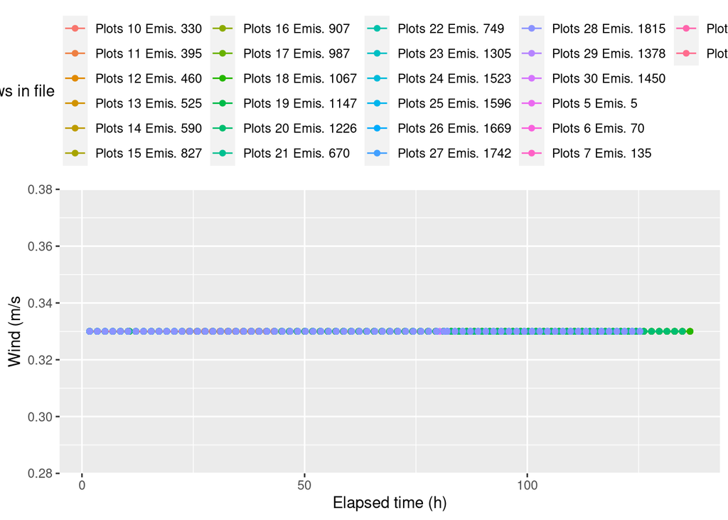

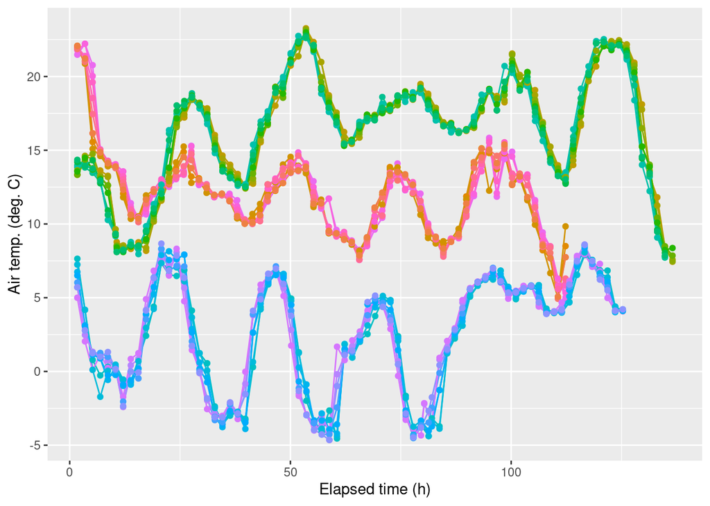

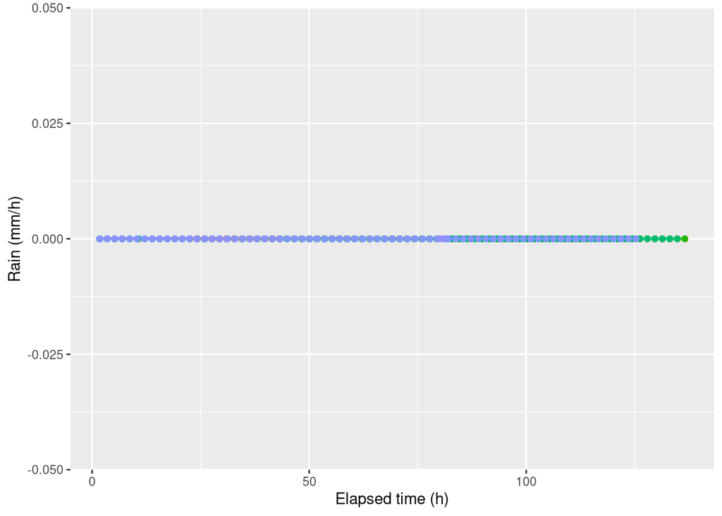

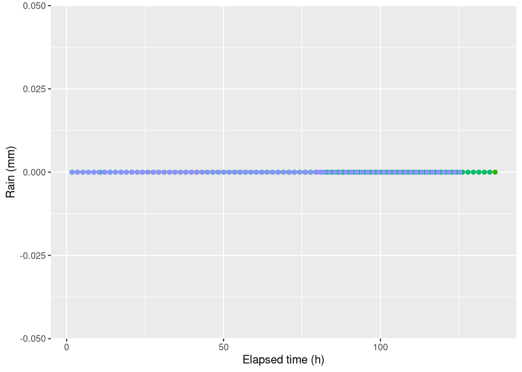

## Manure and application

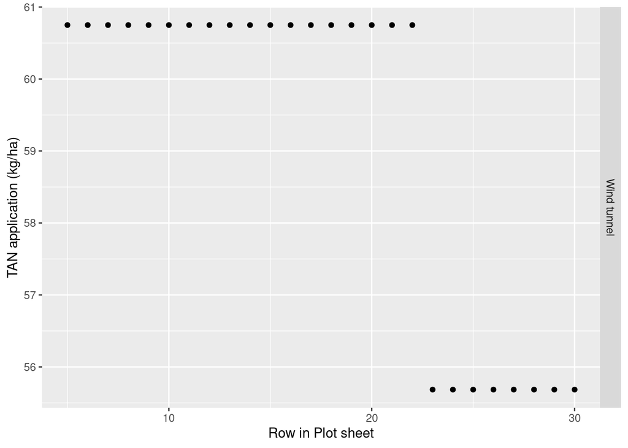

# 10. `dfsumm` summary

```
##
##  1883 rows and 135 columns
##  1883 unique rows
##                                                                                                                                                                                        cpmid
## Class                                                                                                                                                                              character
## Minimum            D:1.I:AU.Pr:NUGA.F:../../data-submitted/03/AU/ALFAM2_template_6_0_220126_JP_20CD21A_JP.xlsx.E:20C.F:Holstebro1.P:1.T:Bomech.R:1.R2:.T:2020-03-06 14:41:00.M:Wind tunnelNA
## Maximum            D:1.I:AU.Pr:NUGA.F:../../data-submitted/03/AU/ALFAM2_template_6_0_220126_JP_20CD21A_JP.xlsx.E:21A.F:Holstebro3.P:9.T:Bomech.R:3.R2:.T:2021-03-16 17:28:00.M:Wind tunnelNA
## Mean                                                                                                                                                                                    <NA>
## Unique (excld. NA)                                                                                                                                                                        26
## Missing values                                                                                                                                                                             0
## Sorted                                                                                                                                                                                  TRUE
##
##                       pub.id      proj     exper      field    plot     rep
## Class              character character character  character numeric numeric
## Minimum                    C      NUGA       20C Holstebro1       1       1
## Maximum                    C      NUGA       21A Holstebro3      12       3
## Mean                    <NA>      <NA>      <NA>       <NA>    6.41    2.04
## Unique (excld. NA)         1         1         3          3       9       3
## Missing values           583         0         0          0       0       0
## Sorted                  TRUE      TRUE      TRUE       TRUE   FALSE   FALSE
##
##                        treat   meas.tech meas.tech.det plot.area     lat
## Class              character   character       logical   numeric numeric
## Minimum               Bomech Wind tunnel          <NA>       0.2    56.4
## Maximum                 Disc Wind tunnel          <NA>       0.2    56.4
## Mean                    <NA>        <NA>          <NA>       0.2    56.4
## Unique (excld. NA)         3           1             0         1       3
## Missing values             0           0          1883         0       0
## Sorted                 FALSE        TRUE          <NA>      TRUE   FALSE
##
##                       long   country      topo    clay    silt    sand      oc
## Class              numeric character character logical logical logical logical
## Minimum               8.87        DK      Flat    <NA>    <NA>    <NA>    <NA>
## Maximum                8.9        DK      Flat    <NA>    <NA>    <NA>    <NA>
## Mean                  8.88      <NA>      <NA>    <NA>    <NA>    <NA>    <NA>
## Unique (excld. NA)       3         1         1       0       0       0       0
## Missing values           0         0         0    1883    1883    1883    1883
## Sorted               FALSE      TRUE      TRUE    <NA>    <NA>    <NA>    <NA>
##
##                    soil.type soil.water soil.water.v soil.moist soil.ph
```

[output cut: 506 more lines]

```
## Maximum                  Trailing shoe          ts        None 2020-06-03
## Mean                              <NA>        <NA>        <NA>       <NA>
## Unique (excld. NA)                   2           2           1          1
## Missing values                       0           0           0          0
## Sorted                           FALSE       FALSE        TRUE       TRUE
##
##                    first.row.int row.plot         first.rows
## Class                    numeric  numeric             factor
## Minimum                        5        5 Plots 10 Emis. 330
## Maximum                     1820       30  Plots 9 Emis. 265
## Mean                         910     17.8 Plots 22 Emis. 749
## Unique (excld. NA)            26       26                 26
## Missing values                 0        0                  0
## Sorted                     FALSE    FALSE              FALSE
##
```